# DS 202: Midterm Exam Solution

Yumou Qiu

10/29/2018

For all of the questions below incorporate the necessary R code directy into your answers. You have 70 mins to complete this exam. At the end of the time period, upload your R Markdown file and the corresponding html file to Canvas.

## Story County Liquor Sales

In this exam, we will study the liquor sales in Iowa. We will use two datasets, `Iowa_Liquor_Stores.csv` and `Story_County_Liquor_Sales_New.csv`, which are posted on **Canvas**. The first dataset records all the active and inactive liquor stores in Iowa as 2018/10/01. Please see the link https://data.iowa.gov/Economy/Iowa-Liquor-Stores/ykb6-ywnd for the information of the variables. You should be able to answer all of the following questions without the help of this website.

The second dataset contains the spirits purchase information of Iowa Class “E” liquor licensees by product and date of purchase from January 1, 2012 to current. The dataset can be used to analyze total spirits sales in Story county, Iowa of individual products at the store level. Class E liquor license, for grocery stores, liquor stores, convenience stores, etc., allows commercial establishments to sell liquor for off-premises consumption in original unopened containers.

We will first consider the **liquor store data `Iowa_Liquor_Stores.csv`**.

### Question #1 (20 points)

- How many records are in the data set, how many variables?
- How many different cities are included in the dataset? Use `filter()` function in `dplyr` package to identify the cities outside Iowa.
- Introduce a new logical variable `Inactive` (TRUE or FALSE) based on `Store.Status`. This variable equal to `TRUE` if `Store.Status = "I"`, otherwise, it is `FALSE`. What is the overall percentage of the inactive liquor store?
- Use the `group_by()` and `summarise()` functions in `dplyr` package to find this percentage of inactive liquor stores for each city.

```r
library(tidyverse)

# Q1
A = read.csv("Iowa_Liquor_Stores.csv", header = TRUE)
str(A)
```

```
## 'data.frame':    1849 obs. of  9 variables:
##  $ Store        : int  2656 2657 2674 2835 2954 3013 3041 3045 3162 3354 ...
##  $ Name         : Factor w/ 1808 levels "1st Stop Beverage Shop",..: 821 813 838 499 508 956 1435 79 1238 1407 ...
##  $ Store.Status : Factor w/ 2 levels "A","I": 1 1 1 1 2 1 1 1 2 1 ...
##  $ Address      : Factor w/ 1792 levels "","1, Grove Rd",..: 976 512 1622 825 1143 724 942 1656 1683 1195 ...
##  $ City         : Factor w/ 424 levels "","Ackley","Adair",..: 85 37 215 61 106 44 78 48 269 97 ...
##  $ State        : Factor w/ 6 levels "","CA","CO","GA",..: 5 5 5 5 5 5 5 5 5 5 ...
##  $ Zip.Code     : Factor w/ 459 levels "","30384","50002",..: 306 208 51 168 95 404 24 114 441 452 ...
##  $ Store.Address: Factor w/ 1795 levels "","1, Grove Rd\nEldridge, IA 52748\n(41.694958, -90.548679)",..: 976 512 1623 826 1145 724 943 1658 1685 1198 ...
##  $ Report.Date  : Factor w/ 1 level "10/01/2018": 1 1 1 1 1 1 1 1 1 1 ...
```

```r
dim(A)
```

```
## [1] 1849    9
```

```r
# Q2
length(unique(A$City))
```

```
## [1] 424
```

```r
A %>% filter(State != "IA") %>% select(-Report.Date, -Store.Address)
```

```
##   Store                  Name Store.Status                   Address
## 1     1   Sazerac Comapny Inc            I 75 Remittance Dr Ste 3312
## 2     2     PERNOD RICARD USA            I             PO BOX 405746
## 3     3   Levecke Corporation            I             PO BOX 101407
## 4  5631 Marion Market & Cafe'            A
## 5  9936       Dash Events LLC            I    1685 W Uintah St. #101
##               City State Zip.Code
## 1          Chicago    IL    60675
## 2          ATLANTA    GA    30384
## 3         PASADENA    CA    91189
## 4
## 5 Colorado Springs    CO    80904
```

```r
# Q3
A = A %>% mutate(Inactive = (Store.Status == "I"))
mean(A$Inactive)
```

```
## [1] 0.1676582
```

```r
# Q4
A1 = A %>% group_by(City) %>% summarise(ave = mean(Inactive, na.rm=TRUE))
```

### Question #2 (20 points)

- Create a new variable `City1` which convert `City` to a character variable.
- Use `filter()` function and the variable `City1` (**NOT `City`**) to select the cities `Albert City, Ames, Boone, Clarion, Clive, Dubuque, Des Moines, Garwin, Iowa City, Jefferson` from the liquor store data. Drop variable `City`.
- For the 10 selected cities, create a summary dataset to record the name of the city and the number of stores in city. Change `City1` back to a factor in the summary dataset. Reorder the levels of `City1` based on the number of their liquor stores.
- Using ggplot2, draw a bar plot that shows the number of the liquor stores for those 10 cities. Make sure the levels of the cities are ordered appropriately (from the previous question). Comment on the result.

```r
# Q1
A = A %>% mutate(City1 = as.character(City))

# Q2
A2 = A %>% filter(City1 %in% c("Albert City", "Ames", "Boone", "Clarion", "Clive", "Dubuque", "Des Moines", "Garwin", "Iowa City", "Jefferson")) %>% select(-City)

# Q3
A3 = A2 %>% group_by(City1) %>% summarise(number = n())
A3 = A3 %>% mutate(City1 = as.factor(City1))
levels(A3$City1)
```

```
##  [1] "Albert City" "Ames"        "Boone"       "Clarion"     "Clive"
##  [6] "Des Moines"  "Dubuque"     "Garwin"      "Iowa City"   "Jefferson"
```

```r
A3 = A3 %>% mutate(City1 = factor(City1, levels = levels(reorder(City1, number, sum))))
levels(A3$City1)
```

```
##  [1] "Albert City" "Garwin"      "Jefferson"   "Clarion"     "Boone"
##  [6] "Clive"       "Ames"        "Iowa City"   "Dubuque"     "Des Moines"
```

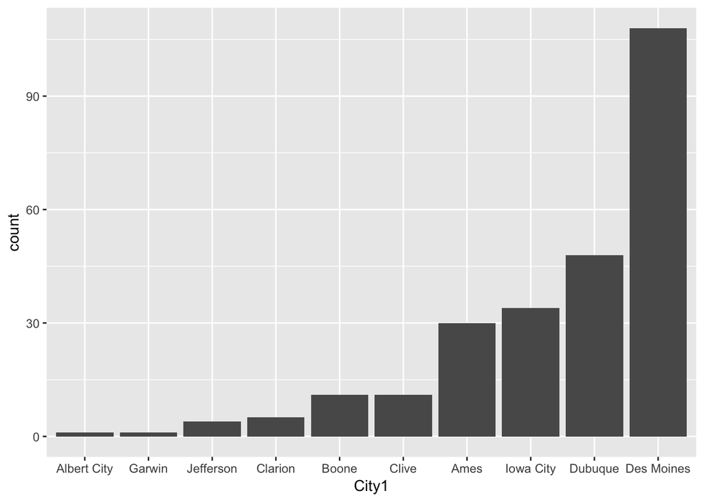

```r
# Q4
A3 %>% ggplot(aes(x = City1)) + geom_bar(aes(weight = number))
```

### Question #3 (15 points)

- Extract the lattitude and longtitude from the variable `Store.Address`. This should be very similar to the practice we did in class.
- Use ggplot2, draw a scatter plot of the location of the liquor stores by the lattitude and longtitude.

```r
# Q1
A = A %>% separate(Store.Address, into = c("Address", "Location"), sep = "\n\\(")
```

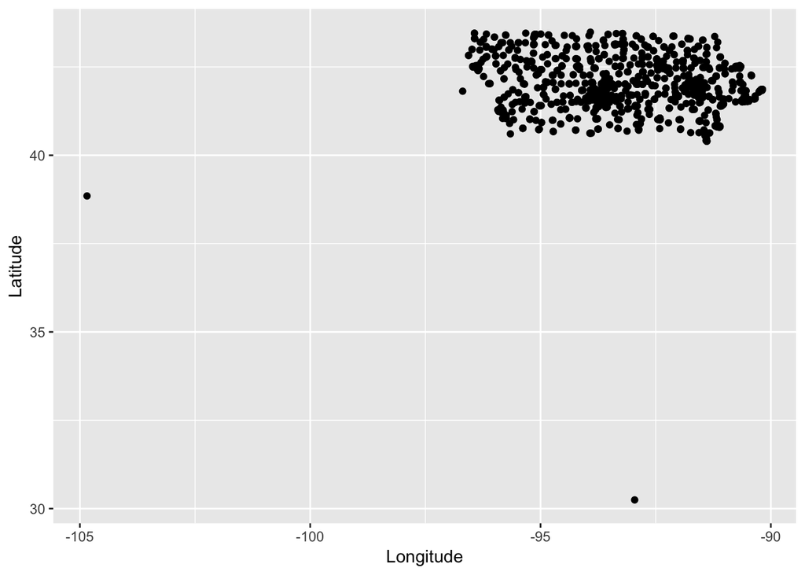

```r
A = A %>% separate(Location, into = c("Latitude", "Longitude"), sep = ",") %>% select(-Address)
A = A %>% separate(Longitude, into = c("Longitude", "drop"), sep = "\\)") %>% select(-drop)
A4 = A %>% mutate(Latitude = as.numeric(A$Latitude), Longitude = as.numeric(A$Longitude)) %>% select(Name, City, Inactive, Latitude, Longitude)

# Q2
A4 %>% ggplot(aes(x = Longitude, y = Latitude)) + geom_point()
```

Now, we use the **liquor sale data `Story_County_Liquor_Sales_New.csv`**. Note that: **Don’t knit your Rmarkdown file often.** It will be slow since this dataset is large. You can run each code chuck or each line separately once the dataset is read into the environment. You can knit after everything is ready.

### Question #4 (30 points)

- Do all the variables have the right type (numeric, factor, character, etc.)? If not, which variables should be converted, and how? (Be careful to convert factor to numeric, first convert factor to character and then character to numeric.)
- Check the variables `County` and `City`. Several of them should be same city or the same county but regarded as different levels in the dataset. Fix them.
- extract year, month and day from the variable `Date`.
- Use the `group_by()` and `summarise()` functions in `dplyr` package to obtain a summarized dataset of total `Volume.Sold..Gallons.` and `Sale..Dollars.` for different combinations of `month`, `year` and `City`. Name this data as `Liquor.Sale.Summary1` with variable names `total.volume` and `total.sale`. (The City should be corrected from the previous questions, and `Sale..Dollars.` should be converted to a numeric variable.)
- Use ggplot2, based on `Liquor.Sale.Summary1`, draw a histogram for the distribution of `total.volume`, facet by cities. Does the result surprise you? Comment.
- Use barplot in ggplot2, based on `Liquor.Sale.Summary1`, compare the `total.sale` between different months, facet by cities (use `scales = "free"` in facet). Color the bar by `years`. Comment on the result.

```r
# Q1
B = read.csv("Story_County_Liquor_Sales_New.csv", header = TRUE)
str(B)
```

```
## 'data.frame':    479752 obs. of  19 variables:
##  $ Invoice.Item.Number  : Factor w/ 479752 levels "INV-00000300001",..: 425559 217676 193415 176417 399060 260857 281491 253555 333971 388023 ...
##  $ Date                 : Factor w/ 1205 levels "01/02/2013","01/03/2012",..: 1088 1050 617 302 667 674 1047 519 796 452 ...
##  $ Store.Number         : int  2501 4509 4105 4509 2500 3943 4102 4105 2501 2500 ...
##  $ Store.Name           : Factor w/ 57 levels "A J'S LIQUOR II",..: 29 1 26 1 32 27 25 26 29 32 ...
##  $ Address              : Factor w/ 88 levels "100, Main St",..: 81 37 14 37 60 71 77 14 81 60 ...
##  $ City                 : Factor w/ 16 levels "Ames","AMES",..: 2 2 11 2 2 11 2 11 2 2 ...
##  $ Zip.Code             : int  50010 50010 50201 50010 50010 50201 50010 50201 50010 50010 ...
##  $ County.Number        : int  85 85 85 85 85 85 85 85 85 85 ...
##  $ County               : Factor w/ 2 levels "Story","STORY": 1 1 1 1 1 1 1 1 1 1 ...
##  $ Category             : int  NA 1081900 1041100 1032080 1012200 1081600 1011100 1071100 1022100 1012100 ...
##  $ Category.Name        : Factor w/ 126 levels "","100 PROOF VODKA",..: 1 82 15 71 98 123 29 9 115 34 ...
##  $ Vendor.Number        : int  255 322 434 35 260 260 260 55 395 55 ...
##  $ Vendor.Name          : Factor w/ 290 levels "3 BADGE CORPORATION",..: 286 203 148 20 65 65 65 227 207 227 ...
##  $ Item.Number          : int  297 75210 31658 34433 6196 67267 25608 57148 89230 11936 ...
##  $ Item.Description     : Factor w/ 4161 levels "\"Beefeater \"\"24\"\"\"",..: 3774 2332 2840 1709 3743 4145 3352 891 9 765 ...
##  $ Pack                 : int  6 6 6 12 6 12 6 6 6 12 ...
##  $ Sale..Dollars.       : Factor w/ 10712 levels "","0.00","1,000.08",..: 8711 2902 3739 5514 7563 5783 1101 1256 8073 3065 ...
##  $ Volume.Sold..Liters. : Factor w/ 345 levels "0.00","0.02",..: 110 335 179 335 19 124 60 137 50 126 ...
##  $ Volume.Sold..Gallons.: num  4.755 2.378 0.925 2.378 0.198 ...
```

```r
B$Volume.Sold..Liters. = as.character(B$Volume.Sold..Liters.)
B$Volume.Sold..Liters. = as.numeric(B$Volume.Sold..Liters.)
B$Sale..Dollars. = as.character(B$Sale..Dollars.)
B$Sale..Dollars. = as.numeric(B$Sale..Dollars.)
# Q2
unique(B$County)
```

```
## [1] Story STORY
## Levels: Story STORY
```

```r
unique(B$City)
```

```
##  [1] AMES       NEVADA     STORY CITY HUXLEY     CAMBRIDGE  SLATER
##  [7] MAXWELL    COLO       Ames       Colo       Story City Huxley
## [13] Slater     Nevada     Maxwell    Roland
## 16 Levels: Ames AMES CAMBRIDGE Colo COLO Huxley HUXLEY Maxwell ... STORY CITY
```

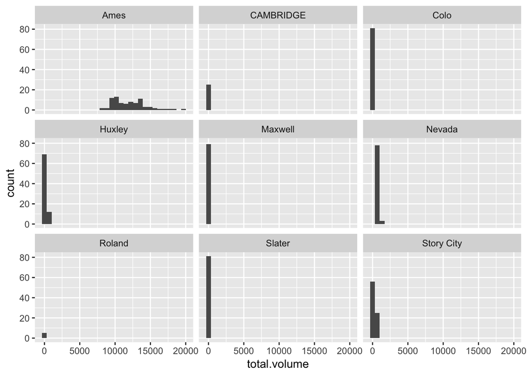

```r
B = B %>% mutate(County = replace(County, County == "STORY", "Story"))
B = B %>% mutate(City = replace(City, City == "AMES", "Ames"))
B = B %>% mutate(City = replace(City, City == "NEVADA", "Nevada"))
B = B %>% mutate(City = replace(City, City == "STORY CITY", "Story City"))
B = B %>% mutate(City = replace(City, City == "COLO", "Colo"))
B = B %>% mutate(City = replace(City, City == "HUXLEY", "Huxley"))
B = B %>% mutate(City = replace(City, City == "SLATER", "Slater"))
B = B %>% mutate(City = replace(City, City == "MAXWELL", "Maxwell"))

# Q3
B = B %>% separate(Date, into = c("Month", "Day", "Year"))

# Q4
Liquor.Sale.Summary1 = B %>% group_by(Month, Year, City) %>% summarise(total.volume = sum(Volume.Sold..Gallons., na.rm = TRUE), total.sale = sum(Sale..Dollars., na.rm = TRUE))

# Q5
Liquor.Sale.Summary1 %>% ggplot(aes(x = total.volume)) + geom_histogram() + facet_wrap(~City)
```

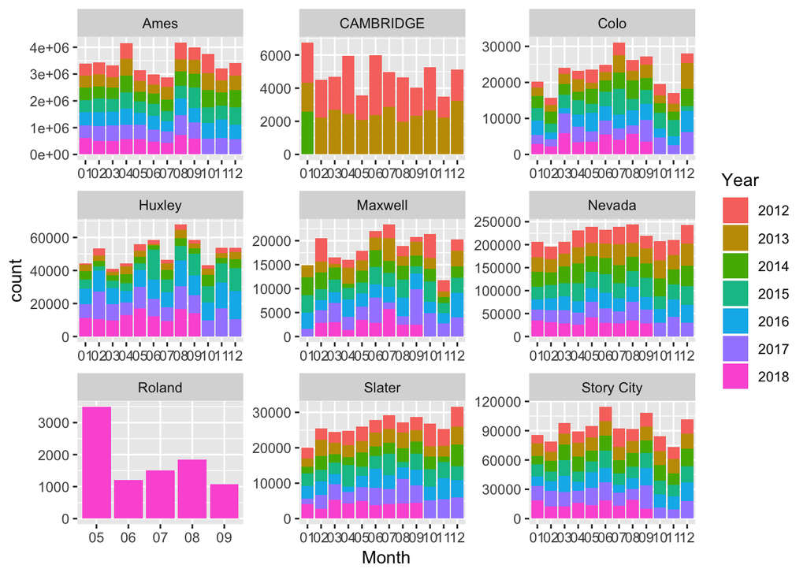

```r
# Q6
Liquor.Sale.Summary1 %>% ggplot(aes(x = Month, fill = Year)) + geom_bar(aes(weight = total.sale)) + facet_wrap(~City, scales = "free")
```

### Question #5 (15 points)

- Use the corrected liquor sale data, first only select the stores in Ames, then summarize the total `Volume.Sold..Gallons.` and `Sale..Dollars.` for each combination of month, year and Store. Call the data `Liquor.Sale.Summary2`.
- Join the latitude and longitude obtained from the liquor store data to `Liquor.Sale.Summary2`.
- Use ggplot2, draw a scatter plot of the location of the Ames liquor stores by the lattitude and longtitude. Indicate the size or color of the points by the total sale of that store.

```r
# Q1
Liquor.Sale.Summary2 = B %>% filter(City == "Ames") %>% group_by(Month, Year, Store.Name) %>% summarise(total.volume = sum(Volume.Sold..Gallons., na.rm = TRUE), total.sale = sum(Sale..Dollars., na.rm = TRUE))

# Q2
Liquor.Sale.Summary3 = left_join(Liquor.Sale.Summary2, A4, by = c("Store.Name" = "Name"))
```

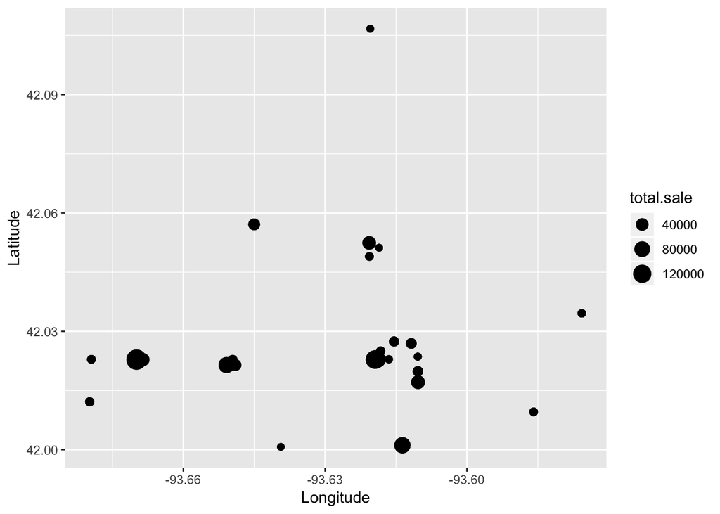

```r
# Q3
Liquor.Sale.Summary3 %>% ggplot(aes(x = Longitude, y = Latitude, size = total.sale)) + geom_point()
```